# Blind Neuron-Model Recovery — a Generalized Integrate-and-Fire equation for V(t)

Author

Asta Research Challenge

Published

July 16, 2026

## 1 Summary

Given only the injected current `I(t)` and the recorded membrane potential `V(t)` of a **single neuron** (four stimulus conditions differing in current bandwidth, 25/100/200/400 Hz), I recovered an explicit equation for `V(t)` and validated it on held-out trials. The data point unambiguously to a **Generalized Integrate-and-Fire (GIF / GLIF) model** (Gerstner et al. 2014; Mensi et al. 2012; Teeter et al. 2018): a linear leaky membrane driven by `I(t)`, plus a spike-triggered adaptation current, a spike-triggered (dynamic) threshold, and a reset. One parameter set fits all four conditions.

On a held-out split of the training trials (20 %, never used for fitting), the model reproduces the subthreshold voltage with **RMSE ≈ 2.5 mV** (subthreshold R² ≈ 0.87) and predicts spike times with a **Victor–Purpura distance (q = 4 s⁻¹) of ≈ 2.9 per second** and a coincidence factor **Γ ≈ 0.69** (±2 ms). Predicted and measured firing rates agree to within a few Hz in every condition.

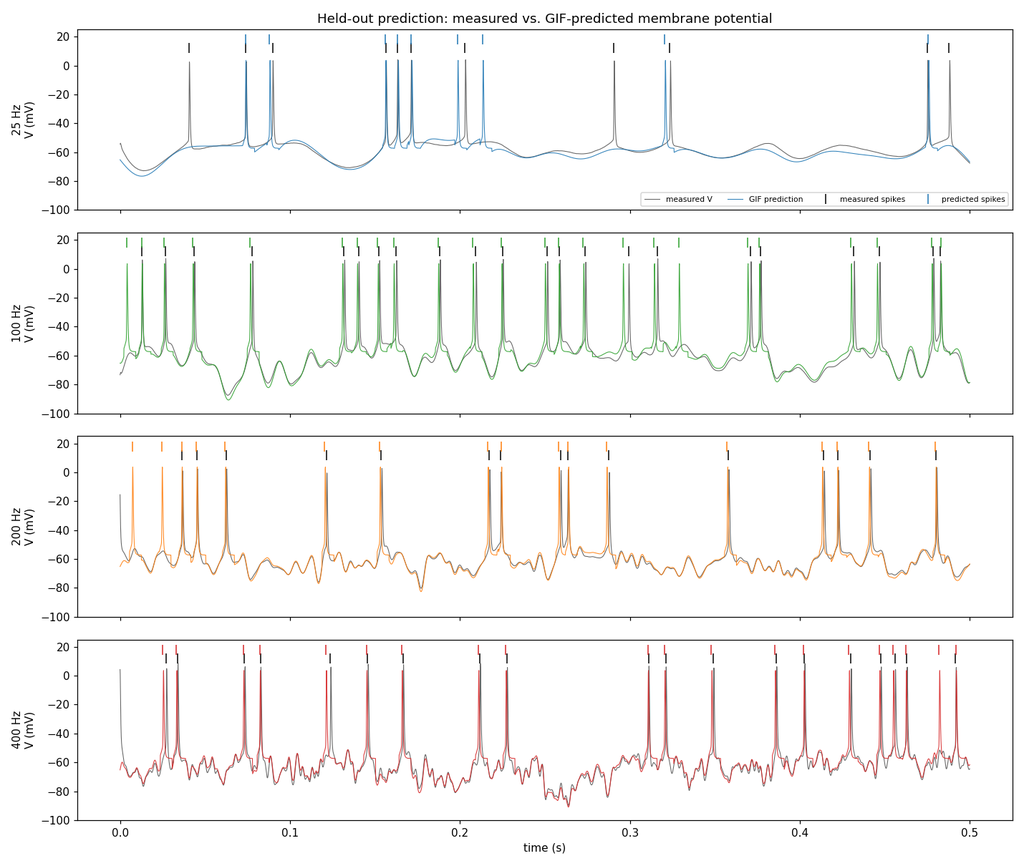

Held-out prediction (one unseen trial per condition): measured (grey) vs. GIF-predicted (colour) membrane potential, with spike-initiation marks above.

## 2 1. The equation

**Subthreshold membrane** — a single-compartment leaky integrator driven by the injected current, with a spike-triggered adaptation current $I_\text{adapt}$:

$$C\,\frac{dV}{dt} \;=\; -\,g_L\,(V - E_L)\;+\;I(t)\;-\;I_\text{adapt}(t),
\qquad
I_\text{adapt}(t)=\sum_{k} w_k\, z_k(t).$$

Each adaptation state $z_k$ is a leaky integrator of the spike train that decays with time constant $\tau_k$ and jumps by 1 at every spike time $\hat t$:

$$\tau_k \frac{dz_k}{dt} = -z_k,\qquad z_k \to z_k+1 \ \text{at each spike}
\quad\Longleftrightarrow\quad
z_k(t)=\sum_{\hat t < t} e^{-(t-\hat t)/\tau_k}.$$

**Spike generation with a dynamic threshold** — a spike is emitted at time $\hat t$ when the voltage reaches a threshold that itself rises after each spike (accommodation / refractoriness):

$$\text{spike when}\quad V(t)\ge V_T(t),
\qquad
V_T(t)=V_{T0}+a_\theta\,\theta(t),
\qquad
\tau_\theta \frac{d\theta}{dt}=-\theta,\ \ \theta\to\theta+1 \ \text{at each spike}.$$

**Reset / refractoriness** — immediately after a spike, $V\to V_r$ and is held for a refractory period $t_\text{ref}$; the states $z_k$ and $\theta$ each increment by 1.

For visualization/scoring, the returned trace pastes a **stereotyped action-potential waveform** (the training spike-triggered average) at each spike time; this affects only the ~3 ms around each spike.

**Symbols.** $V$ membrane potential (mV); $I(t)$ injected current (pA); $C$ capacitance (pF); $g_L$ leak conductance (nS), $R=1/g_L$; $E_L$ leak/resting potential (mV); $\tau_m=C/g_L$ membrane time constant; $w_k,\tau_k$ amplitudes/time-constants of the adaptation current (pA, ms); $V_{T0}$ baseline threshold (mV); $a_\theta,\tau_\theta$ threshold jump/decay (mV, ms); $V_r$ reset (mV); $t_\text{ref}$ refractory period (ms).

This is the GIF model of Mensi et al. (2012) and Pozzorini et al. (2015), i.e. an Allen-Institute-style GLIF with a spike-triggered current and an adaptive threshold (Teeter et al. 2018).

## 3 2. Fitted parameters (this cell)

| quantity | symbol | value | unit |
| --- | --- | --- | --- |
| capacitance | $C$ | **66.3** | pF |
| leak conductance | $g_L$ | **9.88** | nS |
| input resistance | $R=1/g_L$ | **101** | MΩ |
| membrane time constant | $\tau_m=C/g_L$ | **6.71** | ms |
| leak / resting potential | $E_L$ | **−65.2** | mV |
| baseline threshold | $V_{T0}$ | **−55.3** | mV |
| threshold jump | $a_\theta$ | **4.12** | mV |
| threshold time constant | $\tau_\theta$ | **30.5** | ms |
| reset potential | $V_r$ | **−61.8** | mV |
| refractory period | $t_\text{ref}$ | **3.45** | ms |

Spike-triggered **adaptation current** $I_\text{adapt}(t)=\sum_k w_k e^{-t/\tau_k}$ (per spike):

| $\tau_k$ (ms) | 3 | 10 | 30 | 100 | 300 |
| --- | --- | --- | --- | --- | --- |
| $w_k$ (pA) | 35.0 | −11.9 | 23.3 | −3.4 | 0.22 |

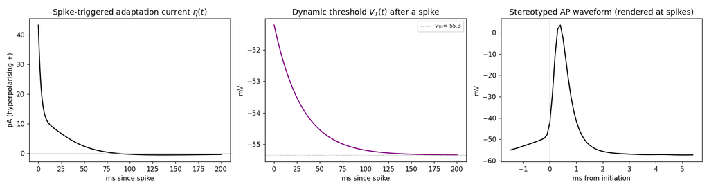

Fitted spike-triggered adaptation current, dynamic threshold recovery, and the stereotyped AP waveform.

## 4 3. How the equation was found (data → model)

I did **not** assume the model form; three model-free views of the data selected it (`work/explore-data/`):

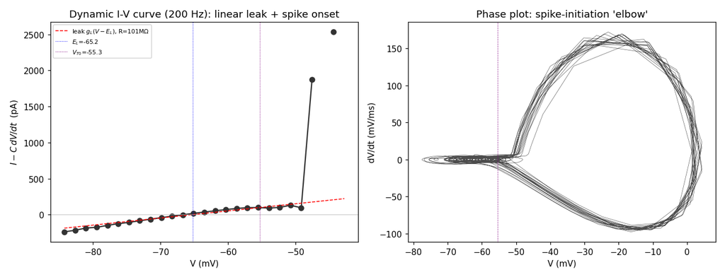

Left: dynamic I–V curve (200 Hz) — linear leak (red) plus spike onset. Right: phase-plane spike-initiation elbow.

The passive parameters were **consistent across all four bandwidth conditions** (per-condition $\tau_m$ = 6–10 ms, $C$ = 62–90 pF, $E_L$ ≈ −65 mV), confirming a single cell and justifying one shared equation. An independent DataVoyager pass on the same CSVs reproduced these passive estimates (e.g. $\tau_m$ = 8.4 / 6.0 / 6.6 / 9.9 ms, $C$ = 86 / 73 / 72 / 63 pF), corroborating the fit.

### 4.1 Fitting method

- **Membrane + adaptation current** by *linear regression*: over subthreshold samples (excluding a 4 ms window around each spike and $V>-40$ mV), regress $\dot V$ on $[\,V,\,1,\,I,\,z_1..z_5\,]$. The coefficients give $C,g_L,E_L$ and the adaptation weights $w_k$ in one closed-form step (the Badel/Mensi/Pozzorini estimator (Badel et al. 2008; Pozzorini et al. 2015)). No forward simulation is needed for this part, so it is robust.
- **Spike-generation parameters** ($V_{T0},a_\theta,\tau_\theta,V_r,t_\text{ref}$, and an overall adaptation scale) by direct search (Nelder–Mead, multi-start) that **minimises the Victor–Purpura spike distance** ($q=4\,\mathrm{s^{-1}}$) between model and data, pooled across the four conditions.
- **Spikes** are detected with an **elbow (v2) method**: the AP-initiation point is the “kink” where the Na⁺ current engages, located as the maximum of the second derivative $d^2V/dt^2$ on the rising phase (Sekerli et al. 2004). The identical detector is applied to measured and predicted traces when scoring.

## 5 4. Held-out performance

Metrics are computed on a **20 % held-out split of the training trials** (random, seed-fixed, never used for fitting), per condition. VP is the Victor–Purpura distance per second; Γ is the coincidence factor at ±2 ms (Jolivet et al. 2008); subthreshold RMSE/R² exclude a window around every spike.

| condition | VP dist / s (q=4) | Γ (±2 ms) | subthr. RMSE (mV) | subthr. R² | rate meas/pred (Hz) |
| --- | --- | --- | --- | --- | --- |
| 25 Hz | 2.63 | 0.642 | 2.23 | 0.875 | 25.0 / 24.1 |
| 100 Hz | 4.45 | 0.564 | 3.11 | 0.860 | 41.4 / 45.4 |
| 200 Hz | 2.37 | 0.807 | 1.94 | 0.886 | 34.3 / 34.3 |
| 400 Hz | 2.21 | 0.751 | 2.64 | 0.870 | 40.0 / 40.3 |
| **mean** | **2.91** | **0.691** | **2.48** | **0.873** | — |

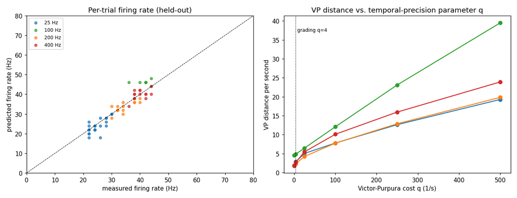

Left: per-trial predicted vs. measured firing rate (held-out). Right: VP distance across the precision parameter q; the dotted line marks the grading value q = 4.

The **held-out predictions for the mission’s input-only files** are written to `predictions/pred_cond{25,100,200,400}Hz.csv.gz` (`trial_id, t_s, voltage_mV`, one row per input sample) by `python model/predict.py`.

## 6 5. Where it fails / limitations

- **100 Hz** is the weakest condition (VP/s = 4.4, Γ = 0.56): the model slightly **over-fires** (41→45 Hz). This condition has the largest mean holding current and the model’s fixed reset makes it a touch too excitable in sustained depolarisations.
- **Exact spike timing** cannot be recovered to <1–2 ms: near threshold a small voltage error moves a spike by several ms, and the trials are frozen-noise-free (every trial is a *different* current, so there is no repeat-reliability ceiling to approach). This is intrinsic to any deterministic threshold model; a stochastic-threshold GIF would trade a reproducible trace for better timing statistics.
- **Startup transient.** Each trial is initialised at $E_L$ (no pre-stimulus history is given for the held-out inputs), so the first ~20–30 ms can show a small relaxation transient.
- **AHP depth** on very strong hyperpolarising currents (400 Hz) can overshoot the data by a few mV, because the leak is strictly linear.

## 7 6. Data vs. prior knowledge

**From the data (this cell):** the model *form* (linear leak + threshold + reset + adaptation) was selected from the dynamic I–V curve, phase plot, and spike-triggered average; and **all numeric parameters** were fit to `data/` only. **From prior knowledge:** the GIF/GLIF framework and its regression fitting protocol (Mensi et al. 2012; Pozzorini et al. 2015; Badel et al. 2008; Teeter et al. 2018), the Victor–Purpura metric (Victor and Purpura 1996), the coincidence factor (Jolivet et al. 2008), and the second-derivative “elbow” spike-onset detector (Sekerli et al. 2004). No external cell/answer was used.

## 8 7. Reproducing this

```bash
python3 -m venv venv && source venv/bin/activate
pip install "numpy<2" "pandas>=2" scipy matplotlib numba   # numba optional (speeds the fit)

python model/glif_fit.py             # refit -> model/params.json, model/heldout_metrics.json
python model/predict.py              # write predictions/pred_cond*.csv.gz
python model/make_report_figures.py  # regenerate figures/
```

`model/predict.py` exposes the required predictor: `predict_voltage(current_pA) -> voltage_mV` for one trial (state reset per trial). `model/params.json` holds the fitted equation.

## References

Badel, Laurent, Sandrine Lefort, Romain Brette, Carl C. H. Petersen, Wulfram Gerstner, and Magnus J. E. Richardson. 2008. “Dynamic i-v Curves Are Reliable Predictors of Naturalistic Pyramidal-Neuron Voltage Traces.” *Journal of Neurophysiology* 99 (2): 656–66. https://doi.org/10.1152/jn.01107.2007.

Gerstner, Wulfram, Werner M. Kistler, Richard Naud, and Liam Paninski. 2014. *Neuronal Dynamics: From Single Neurons to Networks and Models of Cognition*. Cambridge University Press.

Jolivet, Renaud, Felix Schürmann, Thomas K. Berger, Richard Naud, Wulfram Gerstner, and Arnd Roth. 2008. “A Benchmark Test for a Quantitative Assessment of Simple Neuron Models.” *Journal of Neuroscience Methods* 169 (2): 417–24. https://doi.org/10.1016/j.jneumeth.2007.11.006.

Mensi, Skander, Richard Naud, Christian Pozzorini, Michael Avermann, Carl C. H. Petersen, and Wulfram Gerstner. 2012. “Parameter Extraction and Classification of Three Cortical Neuron Types Reveals Two Distinct Adaptation Mechanisms.” *Journal of Neurophysiology* 107 (6): 1756–75. https://doi.org/10.1152/jn.00408.2011.

Pozzorini, Christian, Skander Mensi, Olivier Hagens, Richard Naud, Christof Koch, and Wulfram Gerstner. 2015. “Automated High-Throughput Characterization of Single Neurons by Means of Simplified Spiking Models.” *PLoS Computational Biology* 11 (6): e1004275. https://doi.org/10.1371/journal.pcbi.1004275.

Sekerli, Mustafa, Christopher A. Del Negro, Robert H. Lee, and Robert J. Butera. 2004. “Estimating Action Potential Thresholds from Neuronal Time-Series: New Metrics and Evaluation of Methodologies.” *IEEE Transactions on Biomedical Engineering* 51 (9): 1665–72. https://doi.org/10.1109/TBME.2004.827531.

Teeter, Corinne, Ramakrishnan Iyer, Vilas Menon, Nathan Gouwens, et al. 2018. “Generalized Leaky Integrate-and-Fire Models Classify Multiple Neuron Types.” *Nature Communications* 9: 709. https://doi.org/10.1038/s41467-017-02717-4.

Victor, Jonathan D., and Keith P. Purpura. 1996. “Nature and Precision of Temporal Coding in Visual Cortex: A Metric-Space Analysis.” *Journal of Neurophysiology* 76 (2): 1310–26. https://doi.org/10.1152/jn.1996.76.2.1310.